# Homework 8 Solutions

Alexandra Chronopoulou

## Part I: Practice Questions

### Problem 1

Using the `seatpos` data, perform a PCR analysis with `hipcenter` as the response and `HtShoes`, `Ht`, `Seated`, `Arm`, `Thigh`, and `Leg` as predictors. Select an appropriate number of components and give an interpretation to those you choose. Add `Age` and `Weight` as predictors and repeat the analysis. Use both models to predict the response for predictors taking these values:
$$\begin{align*}
\sf{Age} &= 64.800\\
\sf{Weight} &= 263.700\\
\sf{HtShoes} &= 181.080\\
\sf{Ht} &= 178.560\\
\sf{Seated} &= 91.440\\
\sf{Arm} &= 35.640\\
\sf{Thigh} &= 40.950\\
\sf{Leg} &= 38.790
\end{align*}$$

```r
library(faraway)
library(pls)
data(seatpos)
head(seatpos)
```

```
##   Age Weight HtShoes    Ht Seated  Arm Thigh  Leg hipcenter
## 1  46    180   187.2 184.9   95.2 36.1  45.3 41.3  -206.300
## 2  31    175   167.5 165.5   83.8 32.9  36.5 35.9  -178.210
## 3  23    100   153.6 152.2   82.9 26.0  36.6 31.0   -71.673
## 4  19    185   190.3 187.4   97.3 37.4  44.1 41.0  -257.720
## 5  23    159   178.0 174.1   93.9 29.5  40.1 36.9  -173.230
## 6  47    170   178.7 177.0   92.4 36.0  43.2 37.4  -185.150
```

Obtain the principal components of the design matrix:

```r
X = seatpos[,3:8]
seatpos.pc1 = prcomp(X)
summary(seatpos.pc1)
```

```
## Importance of components:
##                            PC1     PC2     PC3     PC4     PC5     PC6
## Standard deviation     17.1573 2.89689 2.11907 1.56412 1.22502 0.46218
## Proportion of Variance  0.9453 0.02695 0.01442 0.00786 0.00482 0.00069
## Cumulative Proportion   0.9453 0.97222 0.98664 0.99450 0.99931 1.00000
```

Now, we run a principal components regression. We use Cross-Validation to select the optimal number of components:

```r
set.seed(100)
seatpos.pcr1 = pcr(hipcenter~HtShoes+Ht+Seated+Arm+Thigh+Leg, data=seatpos, validation="CV")
summary(seatpos.pcr1)
```

```
## Data:    X dimension: 38 6
##  Y dimension: 38 1
## Fit method: svdpc
## Number of components considered: 6
##
## VALIDATION: RMSEP
## Cross-validated using 10 random segments.
##        (Intercept)  1 comps  2 comps  3 comps  4 comps  5 comps  6 comps
## CV           60.45    37.08    38.14    40.02    39.11    42.94    43.11
## adjCV        60.45    37.00    38.00    39.80    38.89    42.45    42.61
##
## TRAINING: % variance explained
##            1 comps  2 comps  3 comps  4 comps  5 comps  6 comps
## X            94.53    97.22    98.66    99.45    99.93   100.00
## hipcenter    63.80    63.81    63.82    64.98    66.44    66.47
```

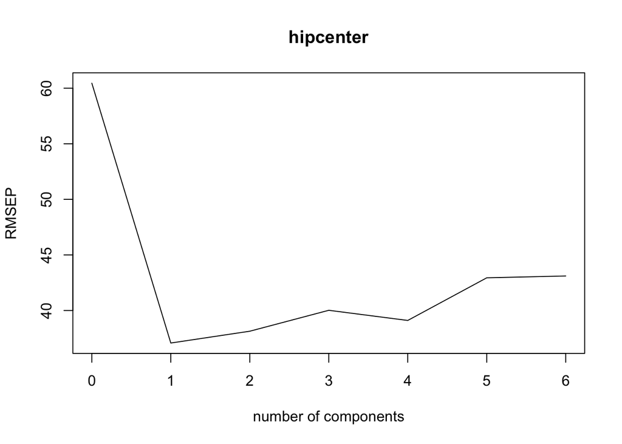

```r
seatpos.pcr1CV<-RMSEP(seatpos.pcr1,estimate="CV")
plot(seatpos.pcr1CV)
```

```r
seatpos.pcr1CV
```

```
## (Intercept)      1 comps      2 comps      3 comps      4 comps      5 comps
##       60.45        37.08        38.14        40.02        39.11        42.94
##     6 comps
##       43.11
```

```r
which.min(seatpos.pcr1CV$val)
```

```
## [1] 2
```

Both the plot and the min CV value indicate that the second term (i.e. one component) is sufficient.

We create a new data.frame with the new values for prediction:

```r
newdata = data.frame(Age=c(64.800), Weight=c(263.700), HtShoes=c(181.080),Ht=c(178.560), Seated=c(91.440), Arm=c(35.64), Thigh=c(40.95), Leg=c(38.79))
newdata
```

```
##    Age Weight HtShoes     Ht Seated   Arm Thigh   Leg
## 1 64.8  263.7  181.08 178.56  91.44 35.64 40.95 38.79
```

```r
predict(seatpos.pcr1, newdata, ncomp=1)
```

```
## , , 1 comps
##
##   hipcenter
## 1 -205.0924
```

Now, let’s add `Age` and `Weight` as predictors .

```r
X2=seatpos[,1:8]
seatpos.pc2 = prcomp(X2)
summary(seatpos.pc2)
```

```
## Importance of components:
##                            PC1     PC2     PC3     PC4     PC5     PC6     PC7
## Standard deviation     38.6977 15.6584 8.43296 2.60449 1.87625 1.46860 1.20085
## Proportion of Variance  0.8193  0.1341 0.03891 0.00371 0.00193 0.00118 0.00079
## Cumulative Proportion   0.8193  0.9534 0.99229 0.99600 0.99792 0.99910 0.99989
##                            PC8
## Standard deviation     0.44405
## Proportion of Variance 0.00011
## Cumulative Proportion  1.00000
```

Observe that the contribution of each component has now changed. Let’s do cross-validation to decide how many components to use:

```r
set.seed(200)
seatpos.pcr2 = pcr(hipcenter~., data=seatpos, validation="CV")
summary(seatpos.pcr2)
```

```
## Data:    X dimension: 38 8
##  Y dimension: 38 1
## Fit method: svdpc
## Number of components considered: 8
##
## VALIDATION: RMSEP
## Cross-validated using 10 random segments.
##        (Intercept)  1 comps  2 comps  3 comps  4 comps  5 comps  6 comps
## CV           60.45    45.18    44.91    39.09    39.65    39.72    41.31
## adjCV        60.45    45.05    44.61    38.81    39.35    39.34    40.84
##        7 comps  8 comps
## CV       45.63    45.95
## adjCV    44.86    45.17
##
## TRAINING: % variance explained
##            1 comps  2 comps  3 comps  4 comps  5 comps  6 comps  7 comps
## X            81.92    95.34    99.23     99.6    99.79    99.91    99.99
## hipcenter    46.36    54.69    65.99     66.2    67.71    67.72    68.62
##            8 comps
## X           100.00
## hipcenter    68.66
```

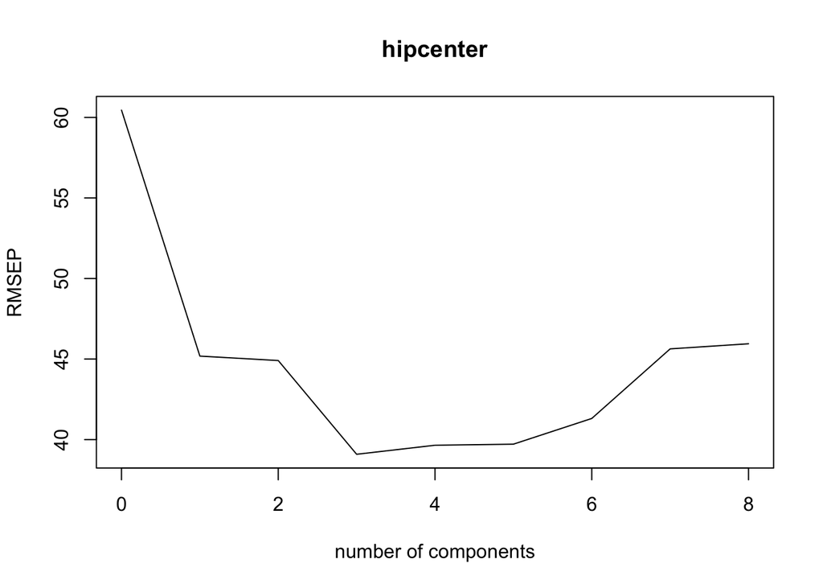

```r
seatpos.pcrCV2<-RMSEP(seatpos.pcr2,estimate="CV")

plot(seatpos.pcrCV2)
```

```r
which.min(seatpos.pcrCV2$val)
```

```
## [1] 4
```

Now, 3 components seem to better explain the variation in the response. With the new model, the predicted value is

```r
predict(seatpos.pcr2, newdata, ncomp=3)
```

```
## , , 3 comps
##
##   hipcenter
## 1 -186.7917
```

### Problem 2

Fit a ridge regression model to the `seatpos` data with `hipcenter` as the response and all other variables as predictors. Take care to select an appropriate amount of shrinkage. Use the model to predict the response at the values of the predictors specified in (1).

```r
library(faraway)
library(MASS)
data(seatpos)
head(seatpos)
```

```
##   Age Weight HtShoes    Ht Seated  Arm Thigh  Leg hipcenter
## 1  46    180   187.2 184.9   95.2 36.1  45.3 41.3  -206.300
## 2  31    175   167.5 165.5   83.8 32.9  36.5 35.9  -178.210
## 3  23    100   153.6 152.2   82.9 26.0  36.6 31.0   -71.673
## 4  19    185   190.3 187.4   97.3 37.4  44.1 41.0  -257.720
## 5  23    159   178.0 174.1   93.9 29.5  40.1 36.9  -173.230
## 6  47    170   178.7 177.0   92.4 36.0  43.2 37.4  -185.150
```

```r
attach(seatpos)

ridgemod = lm.ridge(hipcenter~., data=seatpos, lambda=seq(0, 100, len=1000))

select(lm.ridge(hipcenter~., data=seatpos, lambda=seq(0, 100, len=1000)))
```

```
## modified HKB estimator is 5.425415
## modified L-W estimator is 3.589434
## smallest value of GCV  at 22.32232
```

In ridge regression, we need to find the optimal `lambda`. Here it is equal to 22.32. So, we use this model for prediction:

```r
ridgebest = lm.ridge(hipcenter~., data=seatpos, lambda=22.3223223)
coef(ridgebest)
```

```
##                     Age      Weight     HtShoes          Ht      Seated
## 402.7915365   0.4831513  -0.1044758  -0.7441078  -0.7423828  -1.1953275
##         Arm       Thigh         Leg
##  -1.3611844  -1.3071209  -3.1627248
```

```r
newdata = data.frame(Age=c(64.800), Weight=c(263.700), HtShoes=c(181.080),Ht=c(178.560), Seated=c(91.440), Arm=c(35.64), Thigh=c(40.95), Leg=c(38.79))
newdata
```

```
##    Age Weight HtShoes     Ht Seated   Arm Thigh   Leg
## 1 64.8  263.7  181.08 178.56  91.44 35.64 40.95 38.79
```

```r
pred <- as.matrix(cbind(const=1,newdata)) %*% coef(ridgebest)
pred
```

```
##           [,1]
## [1,] -194.7755
```

## Part II: Homework Questions

### Problem 1

In the following questions choose the correct answer. Justify your answer.

1. The *Lasso*, relative to *Ordinary Least Squares*, is:
   1. More flexible and hence will give improved prediction accuracy when its increase in bias is less than its decrease in variance.
   2. More flexible and hence will give improved prediction accuracy when its increase in variance is less than its decrease in bias.
   3. Less flexible and hence will give improved prediction accuracy when its increase in bias is less than its decrease in variance.
   4. Less flexible and hence will give improved prediction accuracy when its increase in variance is less than its decrease in bias.

**Correct Answer:** *(iii) Less flexible and hence will give improved prediction accuracy when its increase in bias is less than its decrease in variance.*

We know that the OLS give the BLUE (best linear **unbiased** estimators. But, when compared with “biased” estimators, then they tend to have higher bias. We discussed that the LASSO estimators are biased. However, we can control the bias-variance trade-off and reduce the number of coefficients in the model (a stricter penalty will lead many coefficients to be zero) which will ultimately lead in a decrease in the variance (followed by an increase in the bias).

The *Ridge Regression*, relative to *Ordinary Least Squares*, is:

1. More flexible and hence will give improved prediction accuracy when its increase in bias is less than its decrease in variance.
2. More flexible and hence will give improved prediction accuracy when its increase in variance is less than its decrease in bias.
3. Less flexible and hence will give improved prediction accuracy when its increase in bias is less than its decrease in variance.
4. Less flexible and hence will give improved prediction accuracy when its increase in variance is less than its decrease in bias.

**Correct Answer:** *(iii) Less flexible and hence will give improved prediction accuracy when its increase in bias is less than its decrease in variance.* For the same reasons as for the LAsso.

### Problem 2

```r
library(ISLR)
College.new = College
dim(College.new)
```

```
## [1] 777  18
```

```r
#head(College.new)


# Define the Acceptance Rate variable
College.new$Rate = College.new$Accept/College.new$Apps

# Remove the Accept and Apps columns for convenience
College.new$Accept  = College.new$Apps = NULL
#head(College.new)
```

Let’s plot the response against the remaining variables

   In the remaining questions use the `Rate` variable as the response and the other variables as predictors. Do not forget to remove the `Accept` and `Apps` variables from the list of predictors.

   ```r
   # Fix the seed, so that we get the same results (although different versions of R might lead to different results...)
   set.seed(425)

   # Train & Test data sets
   train_index = sample(seq_len(nrow(College.new)), size=floor(0.7*nrow(College.new)))
   train = College.new[train_index,]
   test = College.new[-train_index,]

   # Check the dimensions of the train/test data
   dim(train)
   ```

   ```
   ## [1] 543  17
   ```

   ```r
   dim(test)
   ```

   ```
   ## [1] 234  17
   ```

   Let’s creat the plots of the response against the other predictors in the data set.

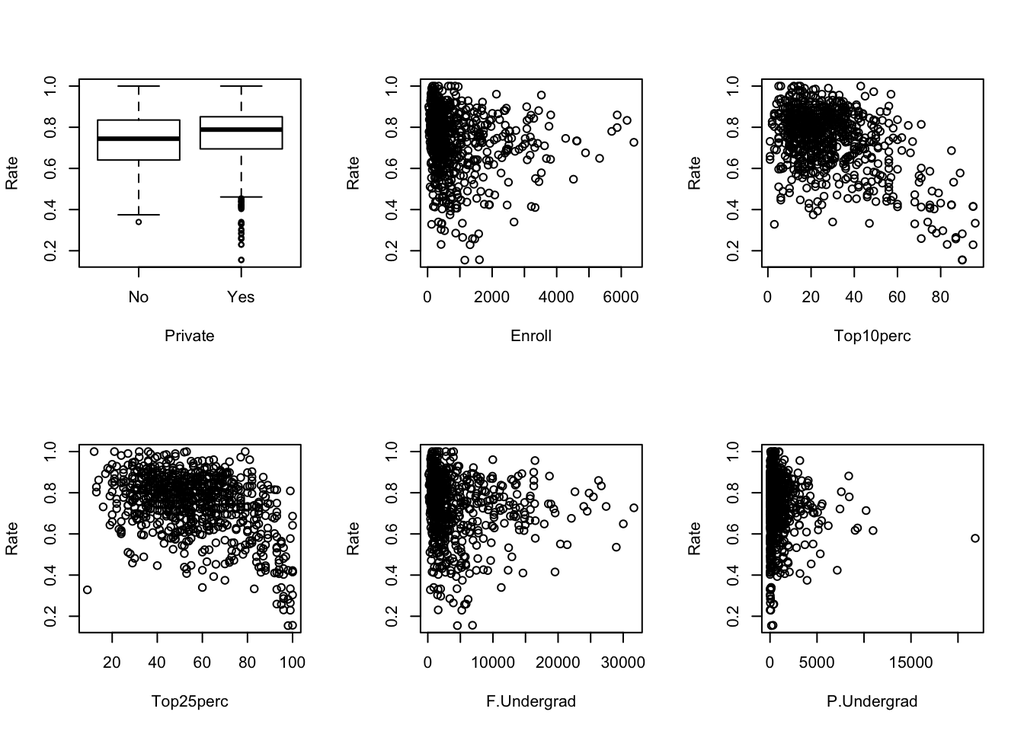

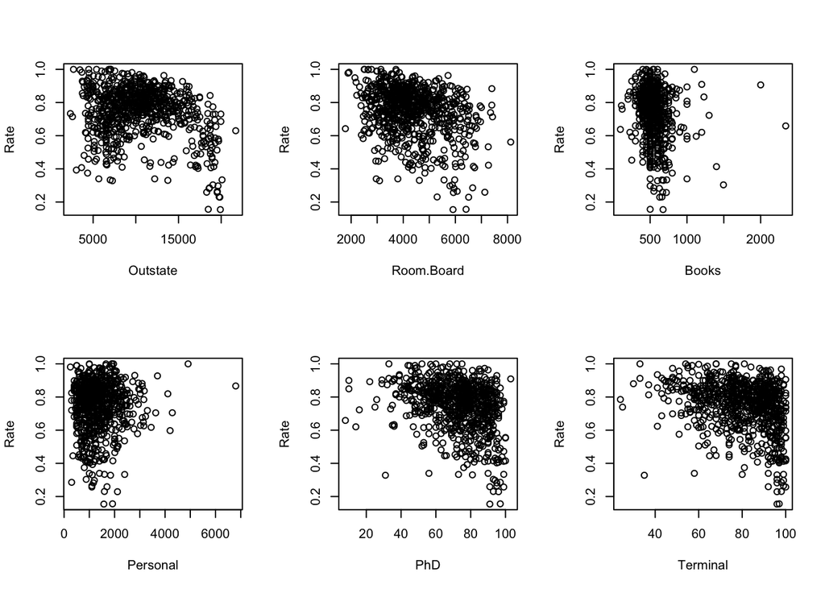

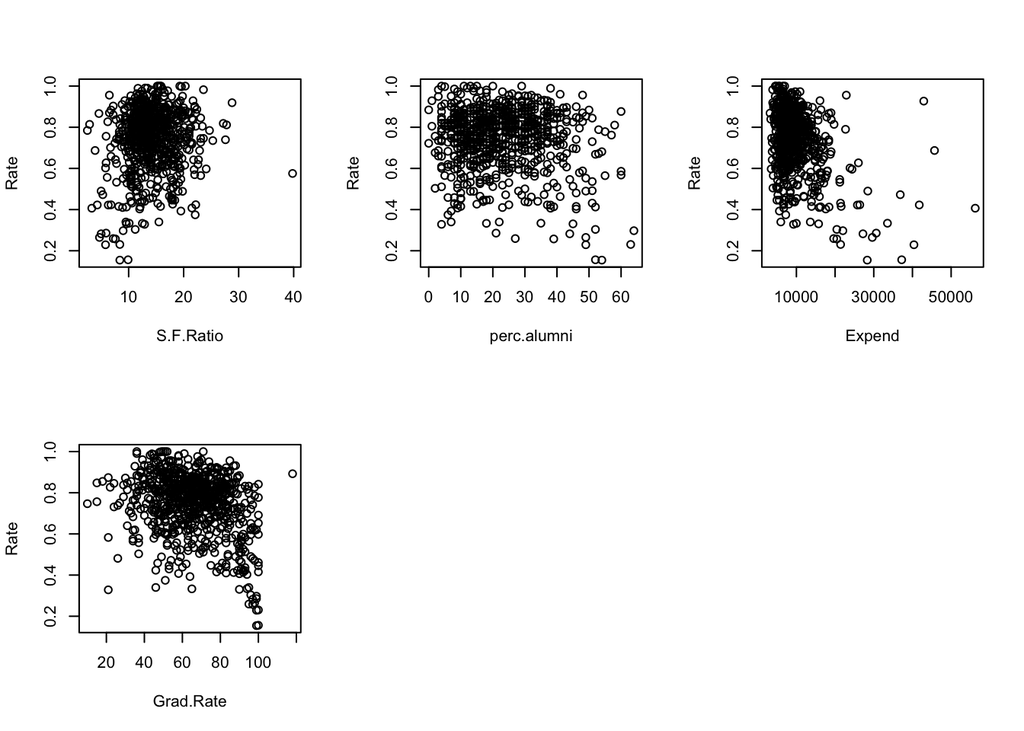

   ```r
   par(mfrow=c(2,3))
   for (i in 1:(ncol(College.new)-1)){
     plot(Rate ~ College.new[,i], data=College.new, xlab=colnames(College.new[i]))
   }
   ```

2. Fit a *linear* model using least squares on the training set, and report the training and testing error obtained.

   ```r
   # Fit a linear model using the training set data.
   college.lm = lm(Rate ~., data=train)
   summary(college.lm)
   ```

   ```
   ##
   ## Call:
   ## lm(formula = Rate ~ ., data = train)
   ##
   ## Residuals:
   ##      Min       1Q   Median       3Q      Max
   ## -0.54021 -0.07275  0.01092  0.08618  0.32043
   ##
   ## Coefficients:
   ##               Estimate Std. Error t value Pr(>|t|)
   ## (Intercept)  1.017e+00  5.591e-02  18.185  < 2e-16 ***
   ## PrivateYes   6.429e-02  1.915e-02   3.357 0.000845 ***
   ## Enroll       5.499e-05  2.385e-05   2.305 0.021544 *
   ## Top10perc   -3.410e-03  7.872e-04  -4.332 1.77e-05 ***
   ## Top25perc    1.844e-04  6.494e-04   0.284 0.776601
   ## F.Undergrad -6.527e-06  4.820e-06  -1.354 0.176308
   ## P.Undergrad -1.155e-05  4.223e-06  -2.735 0.006447 **
   ## Outstate     4.224e-06  2.599e-06   1.626 0.104637
   ## Room.Board  -1.933e-05  7.042e-06  -2.745 0.006259 **
   ## Books       -1.179e-04  3.288e-05  -3.584 0.000370 ***
   ## Personal     1.086e-05  8.674e-06   1.253 0.210941
   ## PhD          1.822e-04  6.381e-04   0.286 0.775363
   ## Terminal     4.292e-04  7.065e-04   0.608 0.543765
   ## S.F.Ratio   -4.234e-03  1.716e-03  -2.467 0.013935 *
   ## perc.alumni  6.130e-04  5.635e-04   1.088 0.277156
   ## Expend      -7.655e-06  1.681e-06  -4.554 6.53e-06 ***
   ## Grad.Rate   -1.205e-03  4.149e-04  -2.905 0.003825 **
   ## ---
   ## Signif. codes:  0 '***' 0.001 '**' 0.01 '*' 0.05 '.' 0.1 ' ' 1
   ##
   ## Residual standard error: 0.1224 on 526 degrees of freedom
   ## Multiple R-squared:  0.3513, Adjusted R-squared:  0.3316
   ## F-statistic: 17.81 on 16 and 526 DF,  p-value: < 2.2e-16
   ```

   The Training and Testing Errors are computed as

   ```r
   ptrain.lm = predict(college.lm, newdata=train[,-17])
   ptest.lm = predict(college.lm, newdata=test[,-17])

   # Mean Square Error
   mean((train$Rate - ptrain.lm)^2)
   ```

   ```
   ## [1] 0.01450403
   ```

   ```r
   mean((test$Rate - ptest.lm)^2)
   ```

   ```
   ## [1] 0.01289495
   ```

   ```r
   # Alternatively, we can calculate the RMSE using the rmse function in the Metrics library
   library(Metrics)
   rmse(train$Rate, ptrain.lm)
   ```

   ```
   ## [1] 0.1204327
   ```

   ```r
   rmse(test$Rate, ptest.lm)
   ```

   ```
   ## [1] 0.1135559
   ```

3. Use `AIC`, `BIC`, and `Adjusted $R^2$` to select a potentially smaller model, from the set of all possible predictors used in the previous question. Report which model each method chose, and the training and testing errors for their chosen model(s).

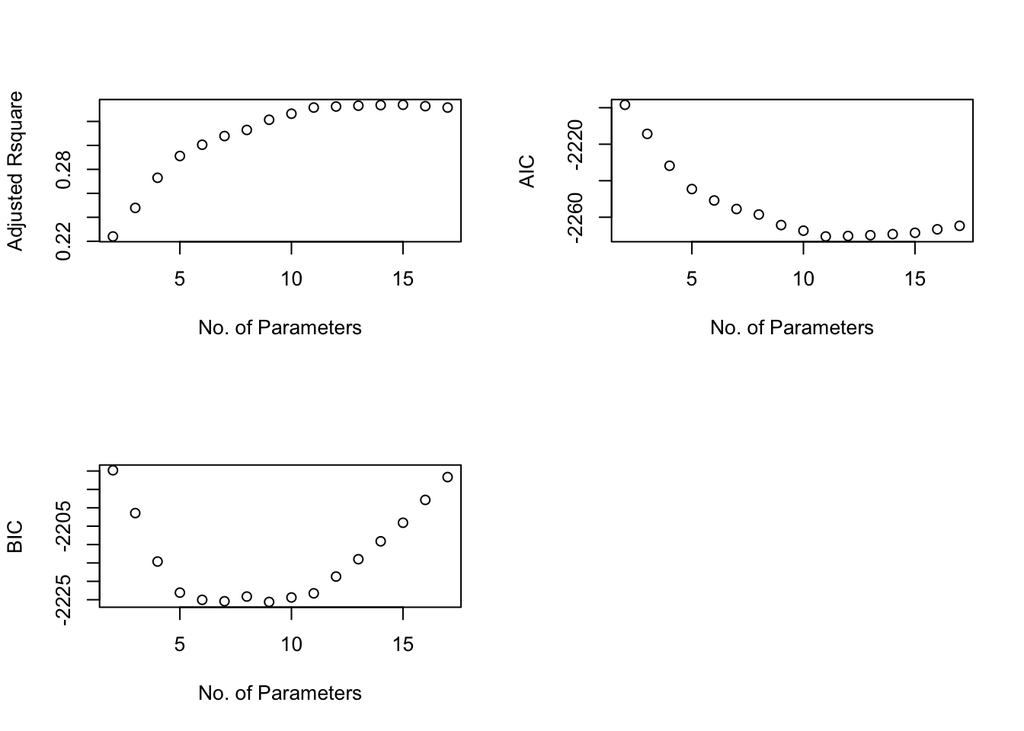

   ```r
   library(leaps)
   college.subsets = regsubsets(Rate ~ ., data=train, nvmax = ncol(train)-1)
   college.subsets.summary = summary(college.subsets)

   n = dim(train)[1]
   msize = 2:17

   par(mfrow=c(2,2))
   plot(msize, college.subsets.summary$adjr2, xlab="No. of Parameters", ylab = "Adjusted Rsquare")
   Aic = n*log(college.subsets.summary$rss/n) + 2*msize;
   plot(msize, Aic, xlab="No. of Parameters", ylab = "AIC");
   Bic = n*log(college.subsets.summary$rss/n) + msize*log(n);
   plot(msize, Bic, xlab="No. of Parameters", ylab = "BIC")
   ```

#### Adjusted $R^2$

   The optimal model according to Adjusted $R^2$ has

   ```r
   which.max(college.subsets.summary$adjr2)
   ```

   ```
   ## [1] 14
   ```

   predictors and it contains the following variables:

   ```r
   college.subsets.summary$which[which.max(college.subsets.summary$adjr2), ]
   ```

   ```
   ## (Intercept)  PrivateYes      Enroll   Top10perc   Top25perc F.Undergrad
   ##        TRUE        TRUE        TRUE        TRUE       FALSE        TRUE
   ## P.Undergrad    Outstate  Room.Board       Books    Personal         PhD
   ##        TRUE        TRUE        TRUE        TRUE        TRUE       FALSE
   ##    Terminal   S.F.Ratio perc.alumni      Expend   Grad.Rate
   ##        TRUE        TRUE        TRUE        TRUE        TRUE
   ```

   The training and testing errors for this model are:

   ```r
   train.adjR = train[,college.subsets.summary$which[which.max(college.subsets.summary$adjr2),-1]]
   test.adjR = test[,college.subsets.summary$which[which.max(college.subsets.summary$adjr2),-1]]

   college.adjR = lm(Rate ~ ., data = train.adjR)

   ptrain.adjR = predict(college.adjR, newdata=train.adjR)
   ptest.adjR = predict(college.adjR, newdata=test.adjR)

   mean((train$Rate - ptrain.adjR)^2)
   ```

   ```
   ## [1] 0.01450865
   ```

   ```r
   mean((test$Rate - ptest.adjR)^2)
   ```

   ```
   ## [1] 0.01285427
   ```

#### AIC

   The optimal model according to AIC has

   ```r
   which.min(Aic)
   ```

   ```
   ## [1] 10
   ```

   predictors and it contains the following variables:

   ```r
   college.subsets.summary$which[which.min(Aic), ]
   ```

   ```
   ## (Intercept)  PrivateYes      Enroll   Top10perc   Top25perc F.Undergrad
   ##        TRUE        TRUE        TRUE        TRUE       FALSE       FALSE
   ## P.Undergrad    Outstate  Room.Board       Books    Personal         PhD
   ##        TRUE        TRUE        TRUE        TRUE       FALSE       FALSE
   ##    Terminal   S.F.Ratio perc.alumni      Expend   Grad.Rate
   ##       FALSE        TRUE       FALSE        TRUE        TRUE
   ```

   The training and testing errors for this model are:

   ```r
   train.aic = train[,college.subsets.summary$which[which.min(Aic),-1]]
   test.aic = test[,college.subsets.summary$which[which.min(Aic),-1]]

   college.aic = lm(Rate ~ ., data = train.aic)

   ptrain.aic = predict(college.aic, newdata=train.aic)
   ptest.aic = predict(college.aic, newdata=test.aic)

   mean((train$Rate - ptrain.aic)^2)
   ```

   ```
   ## [1] 0.0146697
   ```

   ```r
   mean((test$Rate - ptest.aic)^2)
   ```

   ```
   ## [1] 0.01267031
   ```

#### BIC

   The optimal model according to BIC has

   ```r
   which.min(Bic)
   ```

   ```
   ## [1] 8
   ```

   predictors and it contains the following variables:

   ```r
   college.subsets.summary$which[which.min(Bic), ]
   ```

   ```
   ## (Intercept)  PrivateYes      Enroll   Top10perc   Top25perc F.Undergrad
   ##        TRUE        TRUE        TRUE        TRUE       FALSE       FALSE
   ## P.Undergrad    Outstate  Room.Board       Books    Personal         PhD
   ##        TRUE       FALSE       FALSE        TRUE       FALSE       FALSE
   ##    Terminal   S.F.Ratio perc.alumni      Expend   Grad.Rate
   ##       FALSE        TRUE       FALSE        TRUE        TRUE
   ```

   The training and testing errors for this model are:

   ```r
   train.bic = train[,college.subsets.summary$which[which.min(Bic),-1]]
   test.bic = test[,college.subsets.summary$which[which.min(Bic),-1]]

   college.bic = lm(Rate ~ ., data = train.bic)

   ptrain.bic = predict(college.bic, newdata=train.bic)
   ptest.bic = predict(college.bic, newdata=test.bic)

   mean((train$Rate - ptrain.bic)^2)
   ```

   ```
   ## [1] 0.01494921
   ```

   ```r
   mean((test$Rate - ptest.bic)^2)
   ```

   ```
   ## [1] 0.01351091
   ```

   Based on the MSE results, we observe that the models perform quite well both on the training and testing data sets, with the two errors being close. As expected, the training error is slightly higher than the testing error.
4. Fit a *ridge* regression model on the training set, with $\lambda$ chosen by 10-fold cross-validation. Report the training, cross-validated, and testing errors.

   ```r
   # Standardize training and testing data sets
   train.temp = train
   train.temp$Private = NULL
   train.s = cbind(train$Private, as.data.frame(scale(train.temp)))
   names(train.s)[1]='Private'

   test.temp = test
   test.temp$Private = NULL
   test.s = cbind(test$Private, as.data.frame(scale(test.temp)))
   names(test.s)[1]='Private'
   ```

   - Ridge Regression with GCV, but not 10-fold CV

   ```r
   library(MASS)
   model.ridge1 = lm.ridge(Rate~., train.s, lambda=seq(0, 100, len=1000))
   select(model.ridge1)
   ```

   ```
   ## modified HKB estimator is 16.75964
   ## modified L-W estimator is 26.68421
   ## smallest value of GCV  at 20.42042
   ```

   The best $\lambda$ is equal to 20.420. The minimum of the CV errors is

   ```r
   min(model.ridge1$GCV)
   ```

   ```
   ## [1] 0.001262102
   ```

   The training and testing errors for this model are:

   ```r
   model.ridge.gcv = lm.ridge(Rate~., train.s, lambda=20.42)


   train.st = train.s
   train.st$Rate = NULL
   train.st$PrivateYes <- ifelse(train.st$Private == "Yes",1,0)
   train.st$Private = NULL
   train.std = train.st[, c(16,1,2,3,4,5,6,7,8,9,10,11,12,13,14,15)]


   pridge.train = cbind(1,as.matrix(train.std))%*%as.matrix(coef(model.ridge.gcv))

   mean((train.s$Rate - pridge.train)^2)
   ```

   ```
   ## [1] 0.6503105
   ```

   ```r
   test.st = test.s
   test.st$Rate = NULL
   test.st$PrivateYes <- ifelse(test.st$Private == "Yes",1,0)
   test.st$Private = NULL
   test.std = test.st[, c(16,1,2,3,4,5,6,7,8,9,10,11,12,13,14,15)]
   pridge.test = cbind(1,as.matrix(test.std))%*%as.matrix(coef(model.ridge.gcv))

   mean((test.s$Rate - pridge.test)^2)
   ```

   ```
   ## [1] 0.6523748
   ```

   - Ridge Regression with 10-fold CV

   ```r
   library(glmnet)
   xtrain = model.matrix(Rate ~ ., data = train.s)
   ytrain = train.s$Rate
   xtest = model.matrix(Rate ~ ., data = test.s)
   ytest = test.s$Rate

   model.ridge.10cv = cv.glmnet(xtrain, ytrain, nfold = 10, alpha = 0)
   ridge.10cv.lambda  = model.ridge.10cv$lambda.min
   ridge.10cv.lambda
   ```

   ```
   ## [1] 0.08289835
   ```

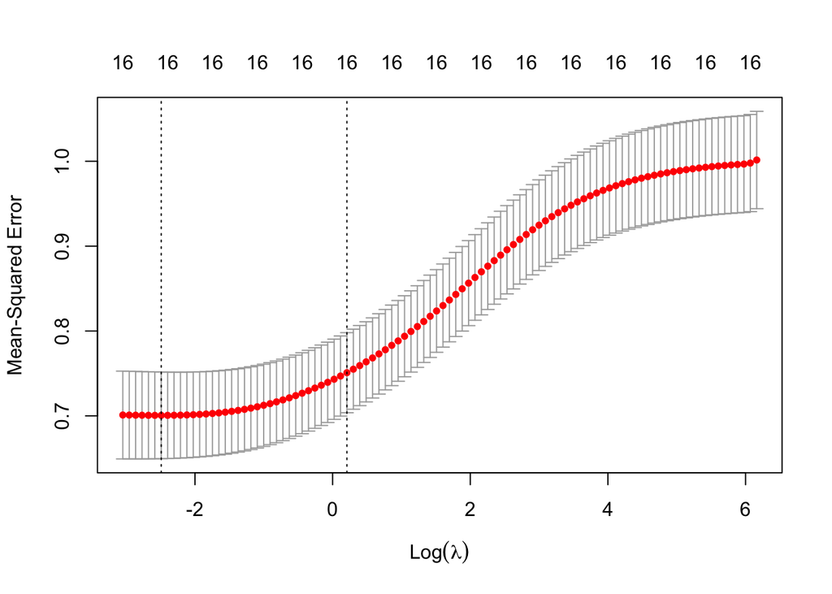

   ```r
   plot(model.ridge.10cv)
   ```

   The cross-validation error is

   ```r
   min(model.ridge.10cv$cvm)
   ```

   ```
   ## [1] 0.7006154
   ```

   The training and testing errors for this model are:

   ```r
   pridge10cv.train = predict(model.ridge.10cv$glmnet.fit , s = ridge.10cv.lambda, newx = xtrain)

   mean((train$Rate - pridge10cv.train)^2 )
   ```

   ```
   ## [1] 0.7789582
   ```

   ```r
   pridge10cv.test  = predict(model.ridge.10cv$glmnet.fit , s = ridge.10cv.lambda, newx = xtest)

   mean((test$Rate-pridge10cv.test)^2)
   ```

   ```
   ## [1] 0.7640498
   ```

5. Fit a *lasso* model on the training set, with $\lambda$ chosen by 10-fold cross-validation. Report which variables are included in the model, and the training, cross-validated, and testing errors.

   ```r
   library(lars)
   ```

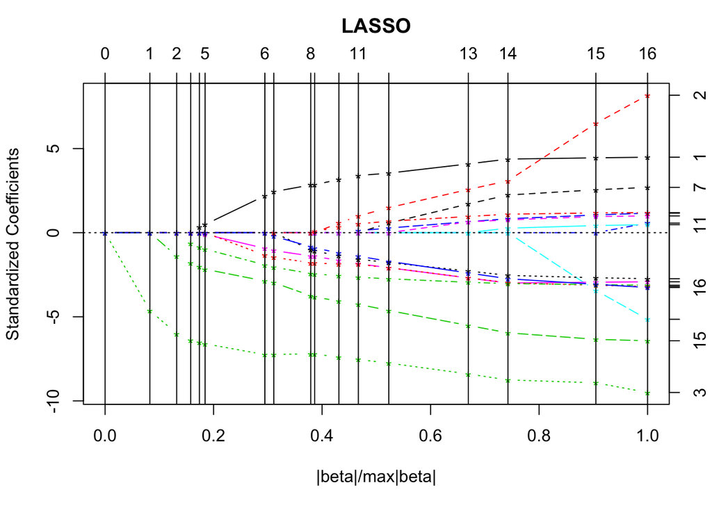

   ```r
   set.seed(425)
   model.lasso1 = lars(as.matrix(train.std),train.s$Rate)
   plot(model.lasso1)
   ```

   ```r
   model.lasso.10cv = cv.glmnet(xtrain, ytrain, nfold = 10, alpha = 1)
   lasso.10cv.t  = model.lasso.10cv$lambda.min
   lasso.10cv.t
   ```

   ```
   ## [1] 0.007210075
   ```

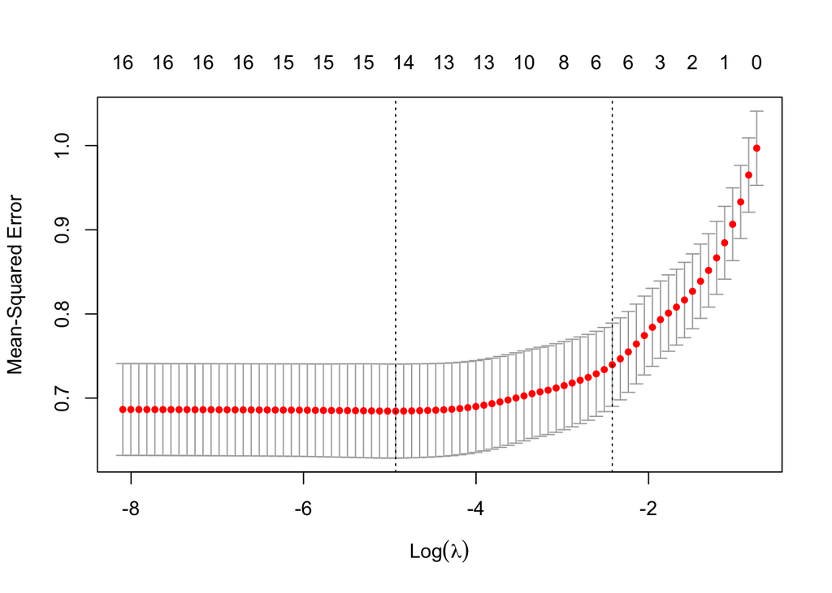

   ```r
   plot(model.lasso.10cv)
   ```

   The cross-validation error is

   ```r
   min(model.lasso.10cv$cvm)
   ```

   ```
   ## [1] 0.6845497
   ```

   The training and testing errors for this model are:

   ```r
   plasso10cv.train = predict(model.lasso.10cv$glmnet.fit , s = lasso.10cv.t, newx = xtrain)

   mean((train$Rate - plasso10cv.train)^2 )
   ```

   ```
   ## [1] 0.7973505
   ```

   ```r
   plasso10cv.test  = predict(model.lasso.10cv$glmnet.fit , s = lasso.10cv.t, newx = xtest)

   mean((test$Rate-plasso10cv.test)^2)
   ```

   ```
   ## [1] 0.7792813
   ```

6. Fit a *PCR* model on the training set, with M chosen by cross-validation. Report the test error obtained, along with the value of M selected by cross-validation.

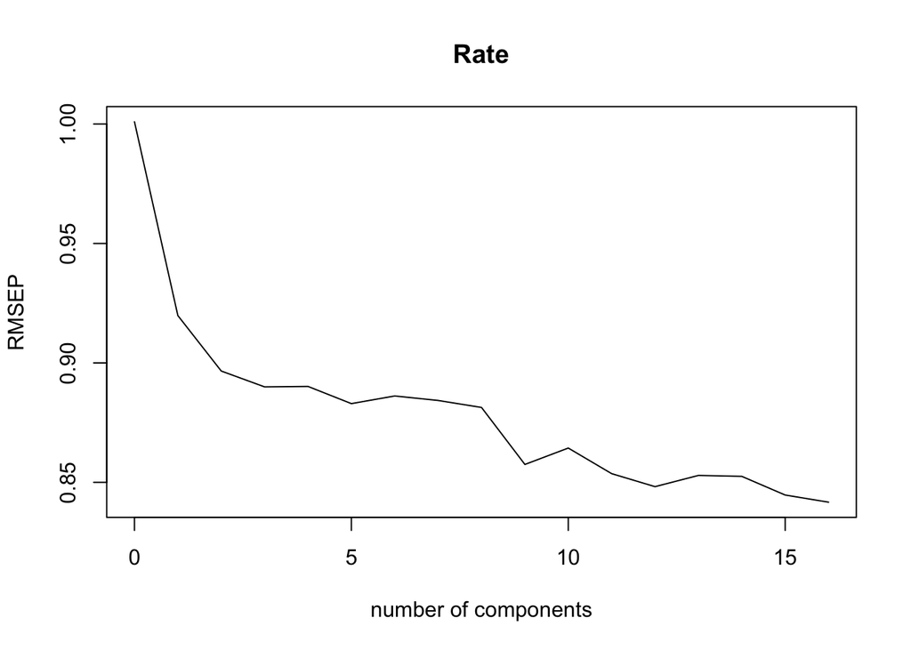

   ```r
   library(pls)
   set.seed(425)

   model.pcr = pcr(Rate ~., data=train.s, validation="CV")
   plot(RMSEP(model.pcr, estimate="CV"))
   ```

   ```r
   # M = components that correspond to min RMSE
   M = which.min(RMSEP(model.pcr, estimate="CV")$val)
   M
   ```

   ```
   ## [1] 17
   ```

   ```r
   #  RMSE
   min(RMSEP(model.pcr, estimate="CV")$val)
   ```

   ```
   ## [1] 0.8416969
   ```

   ```r
   # Testing/ Training Errors
   ptrain.pcr = predict(model.pcr, train.s, ncomp=16)
   ptest.pcr = predict(model.pcr, test.s, ncomp=16)

   mean((train.s$Rate - ptrain.pcr)^2)
   ```

   ```
   ## [1] 0.6474773
   ```

   ```r
   mean((test.s$Rate - ptest.pcr)^2)
   ```

   ```
   ## [1] 0.6579451
   ```

7. Comment on the results obtained. How accurately can we predict the acceptance rate overall? Which approach would you recommend for this data set and why?

   In order to select the best approach for this data, we have to look at the prediction errors in the testing data set, if prediction is our goal. In our case, RIDGE, LASSO and PCR models tend to have a relatively high prediction error on the testing data.